# Analysis of species abundances

```r
library("tidyverse")
```

[output not shown]

```r
source("99_proj_func.R")
```

```r
data_path <- here("data/06_dat_augmented.csv")
dataset <- read_csv(data_path,
                    na = c("nd", "-", "na"),
                    show_col_types = FALSE)
```

### Assessing relationships between species abundance and metadata features

Let’s analyze the diversity between glucose tolerances and BMI groups.

We do this by calculating a distance matrix based on the microbial abundance data, which then can be used to visualize the differences in composition in a reduced dimensionality.

```r
# Pull the class labels for glucose tolerance
glucose_tolerance_labels <- dataset |>
  pull(glucose_tolerance)
# and BMI
BMI_labels <- dataset |>
  pull(BMI_class)

# Select abundance data from data set to calculate distances
abundance_data <- dataset |>
  select(matches("^s_"))

# Calculate Beta diversity based on Bray-Curtis distance
bc_dist <- vegdist(abundance_data, method = "bray")

# Perform PCoA
pcoa_result <- cmdscale(as.dist(bc_dist), k = 2, eig = TRUE)

# Extract eigenvalues and calculate proportion of variance explained
eigenvalues <- pcoa_result |>  pluck("eig")
variance_explained <- eigenvalues / sum(eigenvalues)

# Combine PCoA results with group labels
pcoa_df <- pcoa_result |>
  pluck("points") |>
  as.data.frame() |>
  rename(PCoA1 = V1, PCoA2 = V2) |>
  mutate(glucose_tolerance = glucose_tolerance_labels) |>
  mutate(BMI_class = BMI_labels)
```

[figure not shown]

Let’s analyze the diversity between classes based on microbiota composition.

```r
pcoa_glucose_tolerance <- ggplot(pcoa_df, aes(x = PCoA1, y = PCoA2, color = glucose_tolerance_labels)) +
  geom_point(size = 3) +
  theme_minimal() +
  labs(title = "PCoA of health classes on microbiome composition",
       x = paste0("PCoA1 (", round(variance_explained |>  first() * 100, 2), "%)"),
       y = paste0("PCoA2 (", round(variance_explained |>  nth(2) * 100, 2), "%)"),
       color = "Glucose tolerance")

save_plot_custom(
  plot = pcoa_glucose_tolerance,
  filename = "10_pcoa_glucose_tolerance.jpg"
)
pcoa_glucose_tolerance
```

```
abundances <- dataset |>
  select(sampleID, glucose_tolerance, BMI_class, starts_with("s_"))

pca_fit <- abundances |>
  select(where(is.numeric)) |>
  prcomp(scale = TRUE)

pca_plot <- pca_fit |>
  augment(abundances) |>
  ggplot(aes(.fittedPC1, .fittedPC2)) +
  geom_point(size = 1.5)

save_plot_custom(
  plot = pca_plot,
  filename = "10_pca_plot.jpg"
)
pca_plot
```

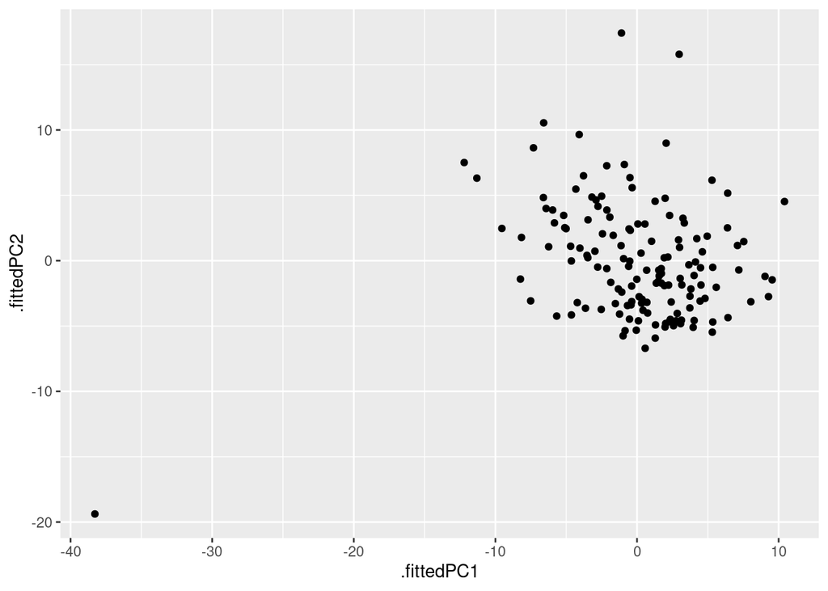

```
pcoa_bmi <- ggplot(pcoa_df, aes(x = PCoA1, y = PCoA2, color = BMI_labels)) +
  geom_point(size = 3) +
  theme_minimal() +
  labs(title = "PCoA of bmi classes on microbiome composition",
       x = paste0("PCoA1 (", round(variance_explained |>  first() * 100, 2), "%)"),
       y = paste0("PCoA2 (", round(variance_explained |>  nth(2) * 100, 2), "%)"),
       color = "BMI class")

save_plot_custom(
  plot = pcoa_bmi,
  filename = "10_pcoa_bmi.jpg"
)
pcoa_bmi
```

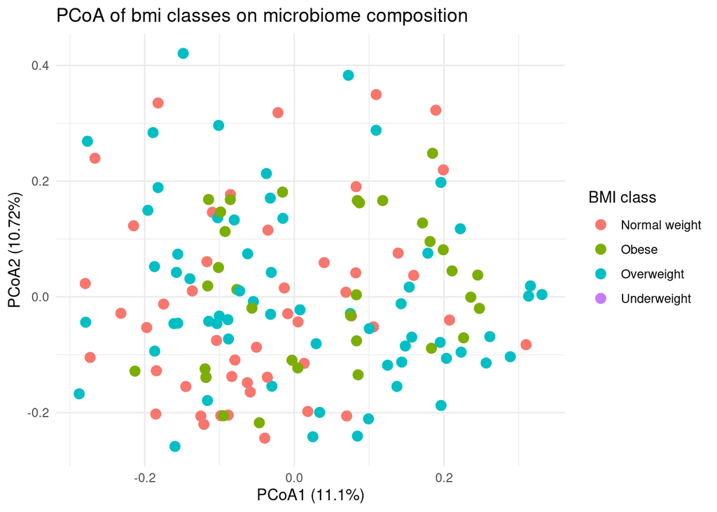

The plots show that the samples do not cluster in any significant way, either for the BMI or for the glucose tolerance, this is in agreement with the observation made so far.

We perform a PERMANOVA test to quantify the difference between the BMI groups, testing the following:

- Null hypothesis : There is no difference in microbial community across composition across the BMI classes

- Alternative hypothesis: There is a difference in microbial community composition across BMI classes.

[output not shown]

We see that there is an outlier in the data that we can remove for visualization sake.

```
outlier <- pca_fit |>
  augment(abundances) |>
  select(-starts_with("s_")) |>
  filter(.fittedPC1 < -30) |>
  pull(sampleID)
```

```
abundances <- abundances |>
  filter(sampleID != outlier)

pca_fit <- abundances |>
  select(where(is.numeric)) |>
  prcomp(scale = TRUE)

variance_explained <- pca_fit |>
  tidy(matrix = "eigenvalues") |>
  mutate(percent_explained = round(percent * 100, 2))

pc1_var <- variance_explained |>
  filter(PC == 1) |>
  pull(percent_explained)
pc2_var <- variance_explained |>
  filter(PC == 2) |>
  pull(percent_explained)

pca_glucose_tolerance <- pca_fit |>
  augment(abundances) |>
  ggplot(aes(.fittedPC1, .fittedPC2, color = glucose_tolerance)) +
  geom_point(size = 1.5) +
  labs(title = "PCA of glucose tolerance classes based on microbiota composition",
       x = str_c("PC1 (", pc1_var, "%)"),
       y = str_c("PC2 (", pc2_var, "%)"),
       color = "Glucose tolerance")

save_plot_custom(
  plot = pca_glucose_tolerance,
  filename = "10_pca_glucose_tolerance.jpg"
)
pca_glucose_tolerance
```

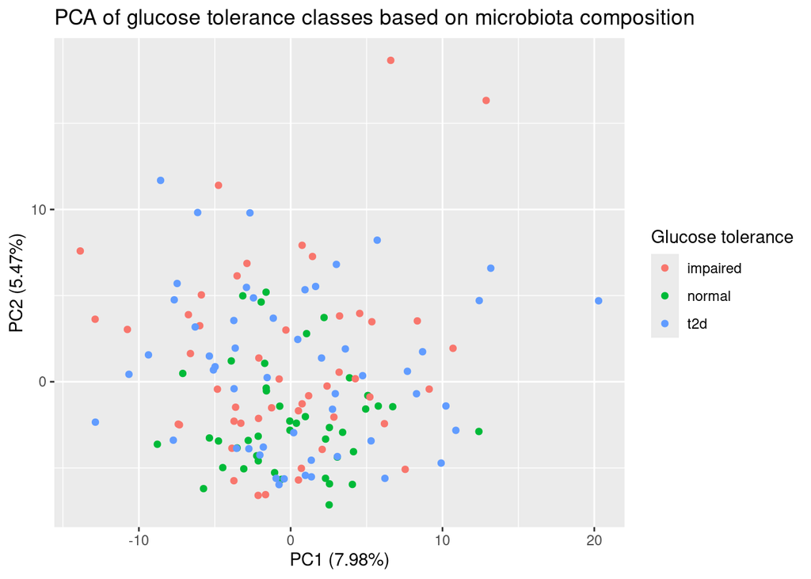

```
pca_BMI <- pca_fit |>
  augment(abundances) |>
  ggplot(aes(.fittedPC1, .fittedPC2, color = BMI_class)) +
  geom_point(size = 1.5) +
  labs(title = "PCA of BMI classes based on microbiota composition",
       x = str_c("PC1 (", pc1_var, "%)"),
       y = str_c("PC2 (", pc2_var, "%)"),
       color= "BMI Class")

save_plot_custom(
  plot = pca_BMI,
  filename = "10_pca_BMI.jpg"
)
pca_BMI
```

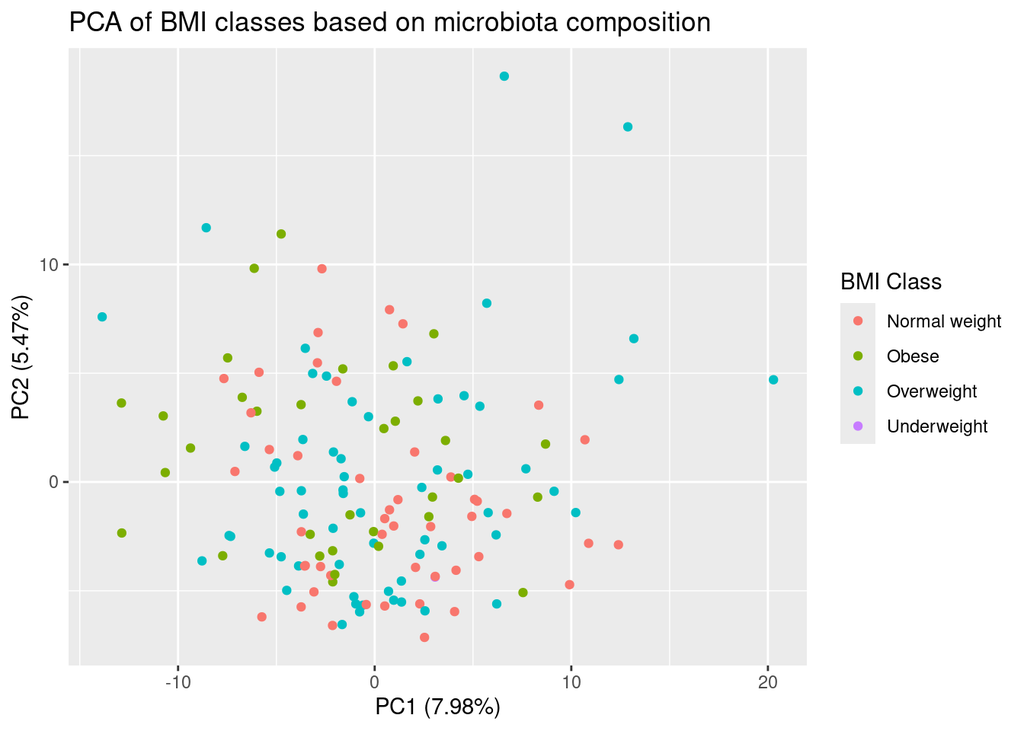

Even by removing the outlier, the plots show that the samples do not cluster in any significant way, either for the BMI or for the glucose tolerance, this is in agreement with the observation made so far.

### Statistical analysis of samples microbiota

```r
#Get a list of the bacteria that have less than n samples where the value is different from 0
n <- 50
sparse_columns <- dataset |>
  select(starts_with("s_")) |>
  pivot_longer(cols = starts_with("s_"),
               names_to = "bacteria",
               values_to = "abundance") |>
  filter(abundance > -2.5) |>
  group_by(bacteria) |>
  summarise(non_zero_samples = n()) |>
  filter(non_zero_samples < n) |>
  pull(bacteria)
```

```r
#splitting dataset into metadata and bacteria data
metadata <- dataset |>
  select(-starts_with("s_"))
```

We will perform the p-value analysis where we compare the bacterial samples from normal and T2D (type 2 diabetes) patients. Therefore, we will remove the impaired samples and sparse data. Next, we will transform the columns and convert the data from wide format to long format to conduct the p-value analysis.

```r
dataset_long <- dataset |>
  filter(glucose_tolerance != "impaired" ) |>
  select(-all_of(sparse_columns)) |>
  pivot_longer(cols = starts_with("s_"),
               names_to = "bacteria",
               values_to = "abundance")
```

Then we group the data by bacteria and nest it. After that, we ungroup it. By doing so, we obtain another tibble, which is a table for each bacterium.

```r
dataset_long_nested <- dataset_long|>
  group_by(bacteria) |>
  nest() |>
  ungroup()

dataset_long_nested
```

```
# A tibble: 191 × 2
   bacteria                          data
   <chr>                             <list>
 1 s_Methanobrevibacter_smithii      <tibble [96 × 30]>
 2 s_Methanobrevibacter_unclassified <tibble [96 × 30]>
 3 s_Methanosphaera_stadtmanae       <tibble [96 × 30]>
 4 s_Actinomyces_graevenitzii        <tibble [96 × 30]>
 5 s_Actinomyces_odontolyticus       <tibble [96 × 30]>
 6 s_Rothia_mucilaginosa             <tibble [96 × 30]>
 7 s_Rothia_unclassified             <tibble [96 × 30]>
 8 s_Bifidobacterium_adolescentis    <tibble [96 × 30]>
 9 s_Bifidobacterium_bifidum         <tibble [96 × 30]>
10 s_Bifidobacterium_catenulatum     <tibble [96 × 30]>
# ℹ 181 more rows
```

Here we see how the data can be pulled out for a choosen bacterium.

```r
#How to get the data
dataset_long_nested |>
  filter(bacteria == "s_Bacteroides_caccae") |>
  pull(data)
```

```
[[1]]
# A tibble: 96 × 30
   sampleID glucose_tolerance is_diseased   age country   bmi BMI_class      hdl
   <chr>    <chr>                   <dbl> <dbl> <chr>   <dbl> <chr>        <dbl>
 1 S118     normal                      0  70.0 sweden   32.7 Obese         1.35
 2 S121     normal                      0  69.3 sweden   29.7 Overweight    2.82
 3 S126     normal                      0  69.5 germany  18.6 Normal weig…  2.72
 4 S127     normal                      0  70.0 sweden   26.6 Overweight    1.4
 5 S137     normal                      0  70.0 sweden   23.2 Normal weig…  2.21
 6 S141     normal                      0  69.4 sweden   25.1 Overweight    2.56
 7 S143     normal                      0  69.5 sweden   28.8 Overweight    2.27
 8 S146     normal                      0  69.5 sweden   36.9 Obese         1.37
 9 S153     normal                      0  70.2 germany  21.6 Normal weig…  2.53
10 S155     normal                      0  70.3 france   21.5 Normal weig…  2.35
# ℹ 86 more rows
# ℹ 22 more variables: ldl <dbl>, hdl_to_ldl_ratio <dbl>,
#   `gad-antibodies` <dbl>, whr <dbl>, wc <dbl>, cholesterol <dbl>,
#   triglycerides <dbl>, creatinine <dbl>, `y-gt` <dbl>, fasting_glucose <chr>,
#   fasting_insulin <dbl>, `HOMA-IR` <chr>, HOMA_category <chr>, hba1c <dbl>,
#   adiponectin <chr>, leptin <chr>, hscrp <dbl>, `c-peptide` <dbl>,
#   tnfa <dbl>, statins <chr>, insulin <chr>, abundance <dbl>
```

Then we fit a linear fitting model to each bacterium.

```r
dataset_long_nested <- dataset_long_nested |>
  group_by(bacteria) |>
  mutate(model_object = map(.x = data,
                            .f = ~lm(formula = abundance ~ is_diseased,
                                     data = .x))) |>
  mutate(model_object_tidy = map(.x = model_object,
                                 .f = ~tidy(x = .x,
                                            conf.int = TRUE,
                                            conf.level = 0.95)))
```

Then we show how a linear model for a random bacterium would look.

```r
#How to get the model
dataset_long_nested |>
  filter(bacteria == "s_Bacteroides_caccae") |>
  pull(model_object_tidy)
```

```
[[1]]
# A tibble: 2 × 7
  term        estimate std.error statistic  p.value conf.low conf.high
  <chr>          <dbl>     <dbl>     <dbl>    <dbl>    <dbl>     <dbl>
1 (Intercept)     7.72     0.865      8.92 3.55e-14     6.00     9.43
2 is_diseased    -1.98     1.16      -1.70 9.18e- 2    -4.29     0.328
```

We unnest the model object so we can access the data and values inside the model.

```r
dataset_estimates <- dataset_long_nested |>
  unnest(model_object_tidy)
dataset_estimates
```

```
# A tibble: 382 × 10
# Groups:   bacteria [191]
   bacteria     data     model_object term  estimate std.error statistic p.value
   <chr>        <list>   <list>       <chr>    <dbl>     <dbl>     <dbl>   <dbl>
 1 s_Methanobr… <tibble> <lm>         (Int…    6.09      1.06      5.73  1.22e-7
 2 s_Methanobr… <tibble> <lm>         is_d…   -1.66      1.43     -1.16  2.49e-1
 3 s_Methanobr… <tibble> <lm>         (Int…   -1.38      0.640    -2.16  3.35e-2
 4 s_Methanobr… <tibble> <lm>         is_d…    1.17      0.862     1.36  1.76e-1
 5 s_Methanosp… <tibble> <lm>         (Int…   -1.17      0.577    -2.02  4.58e-2
 6 s_Methanosp… <tibble> <lm>         is_d…   -0.669     0.777    -0.861 3.92e-1
 7 s_Actinomyc… <tibble> <lm>         (Int…   -0.387     0.585    -0.661 5.10e-1
 8 s_Actinomyc… <tibble> <lm>         is_d…   -0.562     0.788    -0.714 4.77e-1
 9 s_Actinomyc… <tibble> <lm>         (Int…    0.314     0.679     0.462 6.45e-1
10 s_Actinomyc… <tibble> <lm>         is_d…    0.558     0.914     0.610 5.43e-1
# ℹ 372 more rows
# ℹ 2 more variables: conf.low <dbl>, conf.high <dbl>
```

```r
dataset_estimates <- dataset_estimates |>
  filter(term == "is_diseased") |>
  select(bacteria,p.value,estimate,conf.low,conf.high,p.value) |>
  ungroup() |>
  mutate(q.value = p.adjust(p.value),
         is_significant = case_when(q.value <= 0.05 ~ "yes",
                                    q.value > 0.05 ~ "no"))

significant_species <- dataset_estimates |>
  filter(is_significant == "yes")
```

[output not shown]

### Statistical analysis of samples microbiota

Before we can study how the bacterial species may be related to type 2 diabetes, we need to find which bacteria have more than 50 values that are not 0. Even though 0 is a meaningful value in the dataset, we need some data points to vary in order to see if there is a meaning full relationship.

```r
#Get a list of the bacteria that have less than n samples where the value is different from 0
n <- 50
sparse_columns <- dataset |>
  select(starts_with("s_")) |>
  pivot_longer(cols = starts_with("s_"),
               names_to = "backteria",
               values_to = "abundance") |>
  filter(abundance > 0) |>
  group_by(backteria) |>
  summarise(non_zero_samples = n()) |>
  filter(non_zero_samples < n) |>
  pull(backteria)
```

```r
#splitting dataset into metadata and bacteria data
metadata <- dataset |>
  select(-starts_with("s_"))
```

We will perform the p-value analysis where we compare the bacterial samples from normal and T2D (type 2 diabetes) patients. Therefore, we will remove the impaired samples and sparse data. Next, we will transform the columns and convert the data from wide format to long format to conduct the p-value analysis.

```r
dataset_long <- dataset |>
  filter(glucose_tolerance != "impaired" ) |>
  select(-all_of(sparse_columns)) |>
  pivot_longer(cols = starts_with("s_"),
               names_to = "backteria",
               values_to = "abundance")
```

Then we group the data by bacteria and nest it. After that, we ungroup it. By doing so, we obtain another tibble, which is a table for each bacterium.

```r
dataset_long_nested <- dataset_long|>
  group_by(backteria) |>
  nest() |>
  ungroup()

dataset_long_nested
```

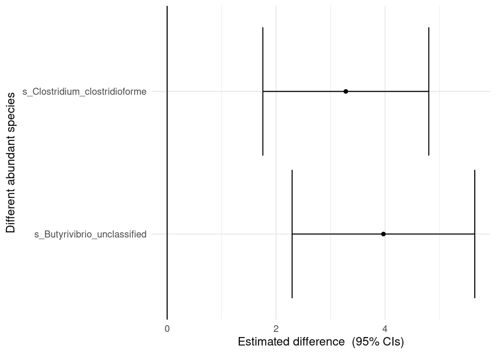

```r
sig_diff_species <- significant_species |>
ggplot(aes(x = estimate,
             y = bacteria,
             xmin = conf.low,
             xmax = conf.high)) +
  geom_vline(xintercept = 0) +
  geom_errorbarh() +
  geom_point() +
  theme_minimal(base_size = 12) +
  theme(plot.title = element_text(hjust = 1)) +
  labs(x = "Estimated difference  (95% CIs)",
       y = expression("Different abundant species"))

save_plot_custom(
  plot = sig_diff_species,
  filename = "10_sig_diff_species.jpg"
)
sig_diff_species
```

```r
# clean environment
# rm(list = ls() |>
#       keep(~ !is.function(get(.))) |>
#       discard(~ . %in% ls()))
```